# Audio Source Separation with Sparsity

Skip to notebook

∿Numerical Tours

← All Python tours

Download notebook[co Open in Colab](https://colab.research.google.com/github/gpeyre/numerical-tours/blob/master/python/audio_2_separation.ipynb)

# Audio Source Separation with Sparsity

Separate several audio sources from a smaller number of mixtures using sparse time-frequency structure. Examine spectrograms, estimate mixing directions, and listen to reconstructed signals to understand both the promise and limitations of masking.

## Run this tour

Run the cells in order with a Python 3 kernel. The first cell locates the companion data and toolbox and installs missing dependencies when needed. All worked examples include their implementation directly in this notebook. Random seeds make comparisons reproducible; you can change them to explore other samples.

```python
# Locate the companion toolbox locally, or fetch it for a standalone/Colab copy.
from pathlib import Path
import importlib.util
import os
import subprocess
import sys

working = Path.cwd()
candidates = [working, working / "python", working.parent / "python"]
python_dir = next((p for p in candidates if (p / "nt_toolbox").is_dir()), None)
if python_dir is None:
    checkout = working / "numerical-tours-support"
    if not checkout.exists():
        subprocess.run(
            [
                "git",
                "clone",
                "--depth",
                "1",
                "--branch",
                "master",
                "https://github.com/gpeyre/numerical-tours.git",
                str(checkout),
            ],
            check=True,
        )
    python_dir = checkout / "python"
os.chdir(python_dir)
if str(python_dir) not in sys.path:
    sys.path.insert(0, str(python_dir))
requirements = python_dir / "requirements.txt"
if any(
    importlib.util.find_spec(name) is None
    for name in [
        "numpy",
        "scipy",
        "matplotlib",
        "skimage",
        "sklearn",
        "pywt",
        "ipywidgets",
        "cvxpy",
        "skfmm",
        "autograd",
        "progressbar",
        "celer",
    ]
):
    subprocess.run(
        [sys.executable, "-m", "pip", "install", "-r", str(requirements)], check=True
    )

import numpy as np
import matplotlib.pyplot as plt

np.random.seed(0)
plt.rcParams.update(
    {
        "figure.figsize": (8, 4),
        "figure.dpi": 100,
        "axes.spines.top": False,
        "axes.spines.right": False,
        "font.size": 11,
        "image.cmap": "gray",
    }
)
%matplotlib inline
```

$\newcommand{\dotp}[2]{\langle #1, #2 \rangle}$ $\newcommand{\enscond}[2]{\lbrace #1, #2 \rbrace}$ $\newcommand{\pd}[2]{ \frac{ \partial #1}{\partial #2} }$ $\newcommand{\umin}[1]{\underset{#1}{\min}\;}$ $\newcommand{\umax}[1]{\underset{#1}{\max}\;}$ $\newcommand{\uargmin}[1]{\underset{#1}{argmin}\;}$ $\newcommand{\norm}[1]{\|#1\|}$ $\newcommand{\abs}[1]{\left|#1\right|}$ $\newcommand{\choice}[1]{ \left\{ \begin{array}{l} #1 \end{array} \right. }$ $\newcommand{\pa}[1]{\left(#1\right)}$ $\newcommand{\diag}[1]{{diag}\left( #1 \right)}$ $\newcommand{\qandq}{\quad\text{and}\quad}$ $\newcommand{\qwhereq}{\quad\text{where}\quad}$ $\newcommand{\qifq}{ \quad \text{if} \quad }$ $\newcommand{\qarrq}{ \quad \Longrightarrow \quad }$ $\newcommand{\ZZ}{\mathbb{Z}}$ $\newcommand{\CC}{\mathbb{C}}$ $\newcommand{\RR}{\mathbb{R}}$ $\newcommand{\EE}{\mathbb{E}}$ $\newcommand{\Zz}{\mathcal{Z}}$ $\newcommand{\Ww}{\mathcal{W}}$ $\newcommand{\Vv}{\mathcal{V}}$ $\newcommand{\Nn}{\mathcal{N}}$ $\newcommand{\NN}{\mathcal{N}}$ $\newcommand{\Hh}{\mathcal{H}}$ $\newcommand{\Bb}{\mathcal{B}}$ $\newcommand{\Ee}{\mathcal{E}}$ $\newcommand{\Cc}{\mathcal{C}}$ $\newcommand{\Gg}{\mathcal{G}}$ $\newcommand{\Ss}{\mathcal{S}}$ $\newcommand{\Pp}{\mathcal{P}}$ $\newcommand{\Ff}{\mathcal{F}}$ $\newcommand{\Xx}{\mathcal{X}}$ $\newcommand{\Mm}{\mathcal{M}}$ $\newcommand{\Ii}{\mathcal{I}}$ $\newcommand{\Dd}{\mathcal{D}}$ $\newcommand{\Ll}{\mathcal{L}}$ $\newcommand{\Tt}{\mathcal{T}}$ $\newcommand{\si}{\sigma}$ $\newcommand{\al}{\alpha}$ $\newcommand{\la}{\lambda}$ $\newcommand{\ga}{\gamma}$ $\newcommand{\Ga}{\Gamma}$ $\newcommand{\La}{\Lambda}$ $\newcommand{\Si}{\Sigma}$ $\newcommand{\be}{\beta}$ $\newcommand{\de}{\delta}$ $\newcommand{\De}{\Delta}$ $\newcommand{\phi}{\varphi}$ $\newcommand{\th}{\theta}$ $\newcommand{\om}{\omega}$ $\newcommand{\Om}{\Omega}$

This numerical tour explore local Fourier analysis of sounds, and its application to source separation from stereo measurements.

```python
import numpy as np
import scipy as scp
import pylab as pyl
import matplotlib.pyplot as plt

from nt_toolbox.general import np, plt, pylab
from nt_toolbox.signal import imageplot, np, plt, pylab

import warnings

%matplotlib inline
```

## Sound Mixing

We load 3 sounds and simulate a stero recording by performing a linear blending of the sounds.

Sound loading.

```python
from nt_toolbox.load_sound import load_sound, np

n = 1024 * 16
s = 3  # number of sounds
p = 2  # number of micros

x = np.zeros([n, 3])
x[:, 0] = load_sound("nt_toolbox/data/bird.wav", n)
x[:, 1] = load_sound("nt_toolbox/data/female.wav", n)
x[:, 2] = load_sound("nt_toolbox/data/male.wav", n)
```

Normalize the energy of the signals.

```python
x = x / np.tile(np.std(x, 0), (n, 1))
```

We mix the sound using a $2\mathrm{x}3$ transformation matrix. Here the direction are well-spaced, but you can try with more complicated mixing matrices.

Compute the mixing matrix

```python
theta = np.linspace(0, np.pi, s + 1)[:-1]
theta[0] = 0.2
M = np.vstack((np.cos(theta), np.sin(theta)))
```

Compute the mixed sources.

```python
y = np.dot(x, np.transpose(M))
```

Display of the sounds and their mix.

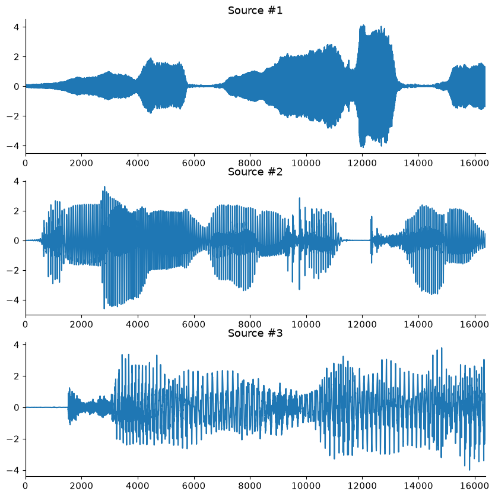

```python
plt.figure(figsize=(10, 10))

for i in range(s):
    plt.subplot(s, 1, i + 1)
    plt.plot(x[:, i])
    plt.xlim(0, n)
    plt.title("Source #%i" % (i + 1))
```

Display of the micro output.

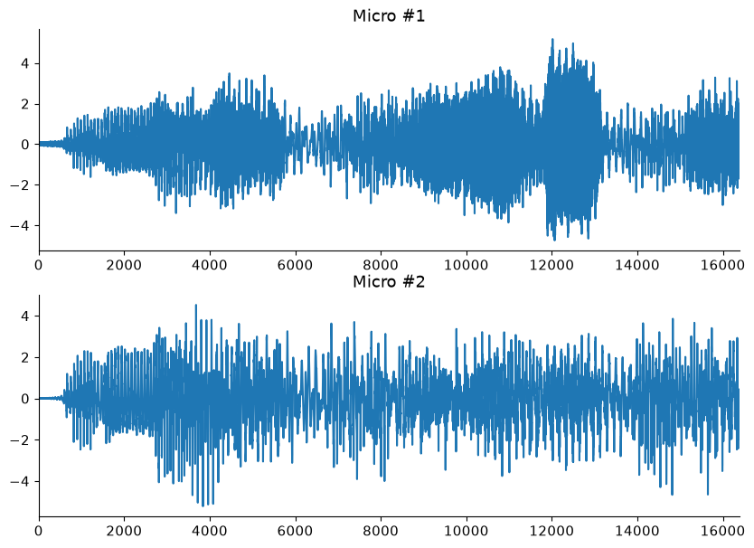

```python
plt.figure(figsize=(10, 7))

for i in range(p):
    plt.subplot(p, 1, i + 1)
    plt.plot(y[:, i])
    plt.xlim(0, n)
    plt.title("Micro #%i" % (i + 1))
```

## Local Fourier analysis of sound.

In order to perform the separation, one performs a local Fourier analysis of the sound. The hope is that the sources will be well-separated over the Fourier domain because the sources are sparse after a STFT.

First set up parameters for the STFT.

```python
w = 128  # size of the window
q = w // 4  # overlap of the window
```

Compute the STFT of the sources.

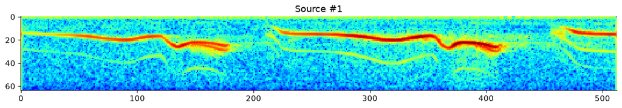

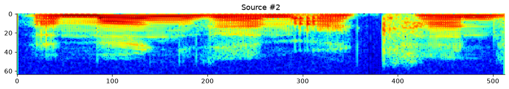

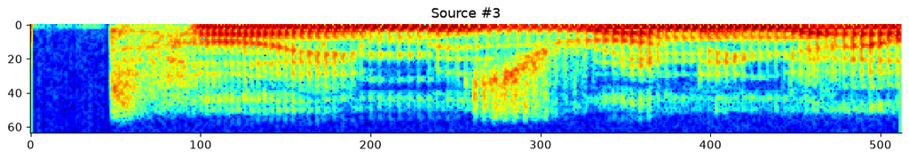

```python
from nt_toolbox.perform_stft import np, perform_stft, pyl
from nt_toolbox.plot_spectrogram import np, plot_spectrogram, plt

X = np.zeros([w, 4 * w + 1, s], dtype=complex)
Y = np.zeros([w, 4 * w + 1, p], dtype=complex)

for i in range(s):
    X[:, :, i] = perform_stft(x[:, i], w, q, n)
    plt.figure(figsize=(15, 10))
    plot_spectrogram(X[:, :, i], "Source #%i" % (i + 1))
```

**Worked example 1**

Compute the STFT of the micros, and store them into a matrix |Y|.

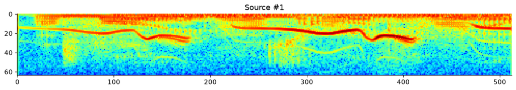

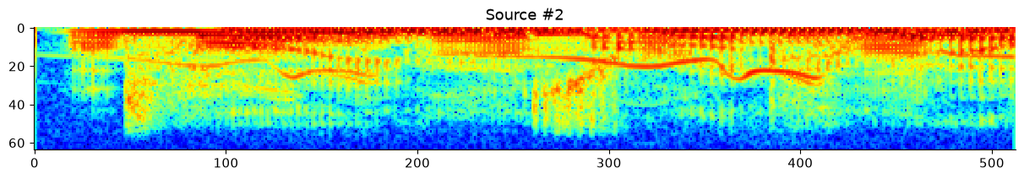

```python
for i in range(p):
    Y[:, :, i] = perform_stft(y[:, i], w, q, n)
    plt.figure(figsize=(15, 10))
    plot_spectrogram(Y[:, :, i], "Source #%i" % (i + 1))
```

## Estimation of Mixing Direction by Clustering

Since the sources are quite sparse over the Fourier plane, the directions are well estimated by looking as the direction emerging from a point clouds of the transformed coefficients.

First we compute the position of the point cloud.

```python
mf = np.shape(Y)[0]
mt = np.shape(Y)[1]
P = np.reshape(Y, (mt * mf, p))
P = np.vstack((np.real(P), np.imag(P)))
```

Display some points in the original (spacial) domain.

Number of displayed points.

```python
npts = 6000
```

Display the original points.

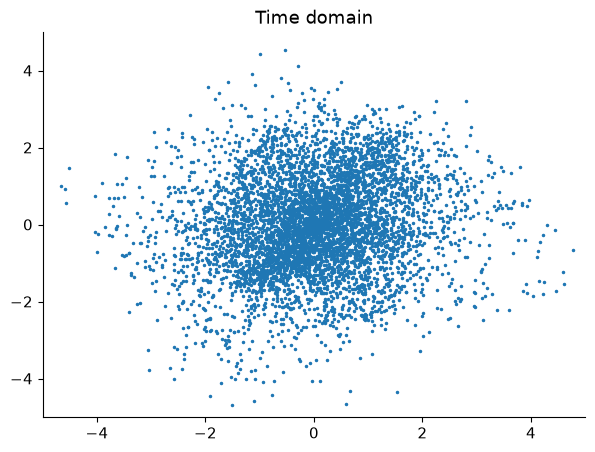

```python
from numpy import random

sel = random.permutation(n)

sel = sel[:npts]

plt.figure(figsize=(7, 5))
plt.plot(y[sel, 0], y[sel, 1], ".", ms=3)
plt.xlim(-5, 5)
plt.ylim(-5, 5)
plt.title("Time domain")
plt.show()
```

**Worked example 2**

Display some points of $P$ in the transformed (time/frequency) domain.

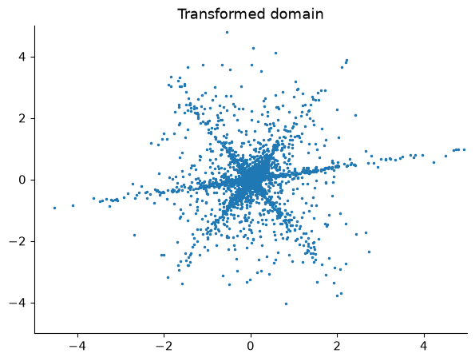

```python
sel = random.permutation(n)

sel = sel[:npts]

plt.figure(figsize=(7, 5))
plt.plot(P[sel, 0], P[sel, 1], ".", ms=3)
plt.xlim(-5, 5)
plt.ylim(-5, 5)
plt.title("Transformed domain")
plt.show()
```

We compute the angle associated to each point over the transformed domain. The histogram shows the main direction of mixing.

```python
import math

nrow = np.shape(P)[0]
Theta = np.zeros(nrow)
for i in range(nrow):
    Theta[i] = math.atan2(P[i, 1], P[i, 0]) % np.pi
```

Display histogram.

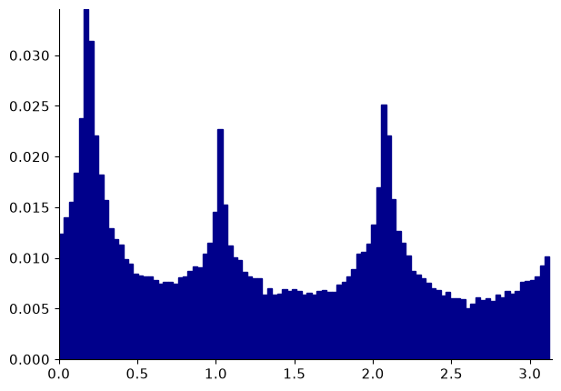

```python
nbins = 100
t = np.linspace(np.pi / 200, np.pi, nbins)
hist = np.histogram(Theta, t)
h = hist[0] / np.sum(hist[0])
t = t[:-1]

plt.figure(figsize=(7, 5))
plt.bar(t, h, width=np.pi / nbins, color="darkblue", edgecolor="darkblue")
plt.xlim(0, np.pi)
plt.ylim(0, np.max(h))
plt.show()
```

**Worked example 3**

The histogram computed from the whole set of points are not peacked enough. To stabilize the detection of mixing direction, compute an histogram from a reduced set of point that have the largest amplitude. Compute the energy of each point. Extract only a small sub-set.

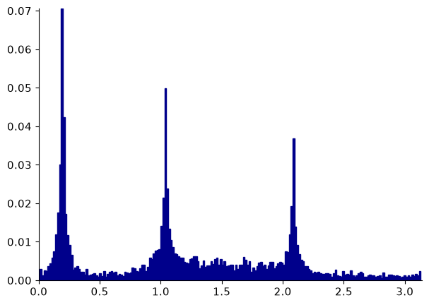

```python
d = np.sum(P**2, 1)
rho = 0.1
v = np.sort(d)
I = np.argsort(d)[::-1]

# transformed points
I = I[np.arange(1, round(rho * len(I)) + 1)]
P1 = P[I, :]

# compute Theta
nrow = np.shape(P1)[0]
Theta = np.zeros(nrow)
for i in range(nrow):
    Theta[i] = math.atan2(P1[i, 1], P1[i, 0]) % np.pi

nbins = 200
hist = np.histogram(Theta, nbins)
h = hist[0] / np.sum(hist[0])
t = hist[1][:-1]

plt.figure(figsize=(7, 5))
plt.bar(t, h, width=np.pi / nbins, color="darkblue", edgecolor="darkblue")
plt.xlim(0, np.pi)
plt.ylim(0, np.max(h))
plt.show()
```

**Worked example 4**

Detect the direction $M_1$ approximating the true direction $M$ by looking at the local maxima of the histogram. First detect the set of local maxima, and then keep only the three largest. Sort in descending order.

```python
s1 = np.hstack((np.arange(2, nbins + 1), np.array([nbins - 1]))) - 1
s2 = np.hstack((np.array([2]), (np.arange(1, nbins)))) - 1
I = np.where((h[s1] < h) & (h[s2] < h))
v = np.sort(h[I])
u = np.argsort(h[I])[::-1]
theta1 = t[I[0][u[:3]]]
M1 = np.vstack((np.cos(theta1), np.sin(theta1)))
print("--- M ---")
print(M)
print("--- M1 ---")
print(M1)
```

```
--- M ---
[[ 0.98006658  0.5        -0.5       ]
 [ 0.19866933  0.8660254   0.8660254 ]]
--- M1 ---
[[ 0.98192131  0.50842815 -0.49475086]
 [ 0.18928959  0.86110441  0.86903486]]
```

## Separation of the Sources using Clustering

Once the mixing direction are known, one can project the sources on the direction.

We compute the projection of the coefficients Y on each estimated direction.

```python
A = np.reshape(Y, (mt * mf, p))
```

Compute the projection of the coefficients on the directions.

```python
C = abs(np.dot(np.transpose(M1), np.transpose(A)))
```

At each point $x$, the index $I(x)$ is the direction which creates the largest projection.

$I$ is the index of the closest source.

```python
tmp = np.max(C, 0)
I = np.argmax(C, 0)
I = np.reshape(I, (mf, mt)) + 1
```

An additional denoising is achieved by removing small coefficients.

```python
T = 0.05
D = np.sqrt(np.sum(abs(Y) ** 2, 2))
I = I * (D > T)
```

We can display the segmentation of the time frequency plane.

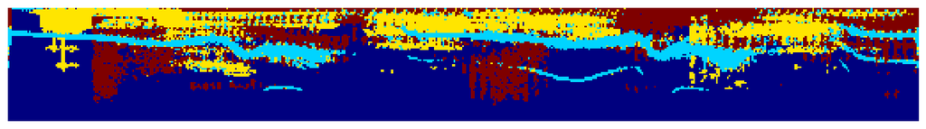

```python
plt.figure(figsize=(15, 10))
imageplot(I[: mf // 2, :])
plt.imshow(I[: mf // 2, :], cmap=plt.get_cmap("jet"), interpolation="nearest")
plt.show()
```

The recovered coefficients are obtained by projection.

```python
Proj = np.dot(np.transpose(M1), np.transpose(A))
Xr = np.zeros([w, 4 * w + 1, s], dtype=complex)
for i in range(s):
    Xr[:, :, i] = np.reshape(Proj[i, :], (mf, mt)) * (I == i)
```

The estimated signals are obtained by inverting the STFT.

```python
xr = np.zeros([n, s])
for i in range(s):
    xr[:, i] = perform_stft(Xr[:, :, i], w, q, n)
```

One can display the recovered signals.

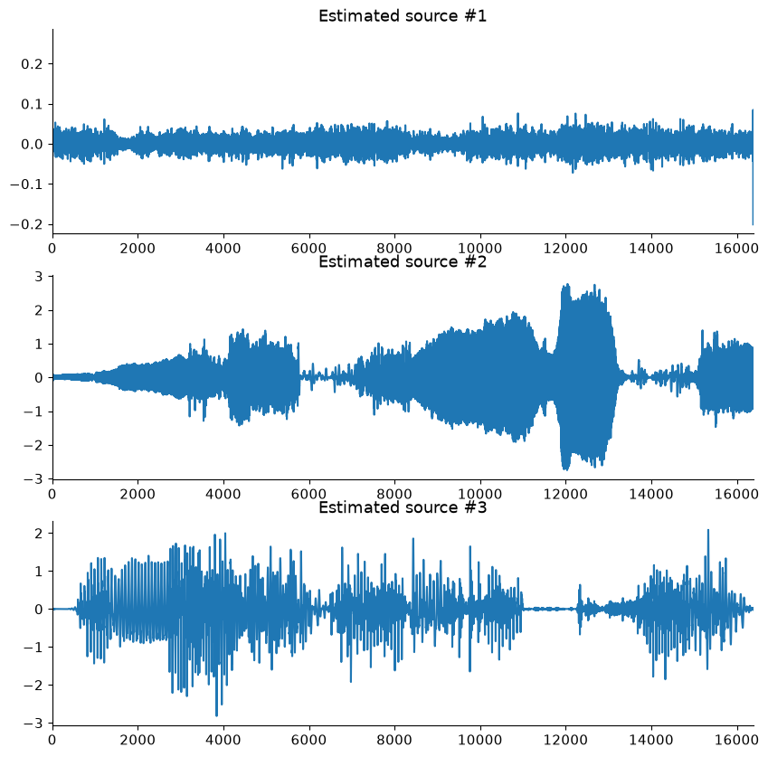

```python
plt.figure(figsize=(10, 10))

for i in range(s):
    plt.subplot(s, 1, i + 1)
    plt.plot(xr[:, i])
    plt.xlim(0, n)
    plt.title("Estimated source #%i" % (i + 1))
```

One can listen to the recovered sources.

```python
i = 1
from IPython.display import Audio

Audio(x[:, i], rate=15000)
```

[interactive chart not shown]

```python
Audio(xr[:, i], rate=15000)
```

[interactive chart not shown]

## References and further reading

- Özgür Yılmaz and Scott Rickard. [Blind Separation of Speech Mixtures via Time-Frequency Masking](https://doi.org/10.1109/TSP.2004.828896). 2004, IEEE Transactions on Signal Processing 52(7), 1830–1847. Separating audio sources through sparse time-frequency structure.
- Aapo Hyvärinen and Erkki Oja. Independent Component Analysis: Algorithms and Applications. 2000, Neural Networks 13(4–5), 411–430. Statistical assumptions and identifiability in blind source separation.
- Stéphane Mallat. [A Wavelet Tour of Signal Processing: The Sparse Way](https://www.di.ens.fr/~mallat/biblio.html). 2009, 3rd ed., Academic Press. Multiresolution analysis, sparse approximation, and wavelet algorithms.
- Gabriel Peyré. [Advanced Signal, Image and Surface Processing](https://www.numerical-tours.com/book/AdvancedSignalProcessing.pdf). 2010, course notes. A mathematical companion to the Numerical Tours.
- Pauli Virtanen et al.. [SciPy 1.0: Fundamental Algorithms for Scientific Computing in Python](https://doi.org/10.1038/s41592-019-0686-2). 2020, Nature Methods 17, 261–272. The numerical routines used for transforms, interpolation, and optimization.

**On this page**